[figure not shown]

# skeleton ostluft/readthedown with pandoc-crossref

# Features

## Cross referencing

The skeleton is using lierdakil/pandoc-crossref. This requires the installation of pandoc-crossref with a compatible version of pandoc. Additional a knitr hook to add the necessaries labels is needed.

In Addition the template supports bookdown. Use `use_bookdown: TRUE` in the yaml header to use the `bookdown::html_document2()` renderer.

Both solutions have their merits and disadvantages. pandoc-crossref is more configurable, but also needs more setup. bookdown one the other hand has [additionals features](https://bookdown.org/yihui/bookdown/motivation.html).

## lightbox support

Using the [Magnific popup](http://dimsemenov.com/plugins/magnific-popup/) lightbox plugin for plots and images. To enable the plugin set `lightbox: TRUE` and for gallery support `gallery: TRUE` in the yaml header. Fore more infos see Kapitel 4.

## minimal pdf support

The file `ostluft_header.tex` includes the minimal changes to create a pdf output. Search for `% OSTLUFT` to inspect the changes.

# Cross Referencing

## plots

### simple single plot

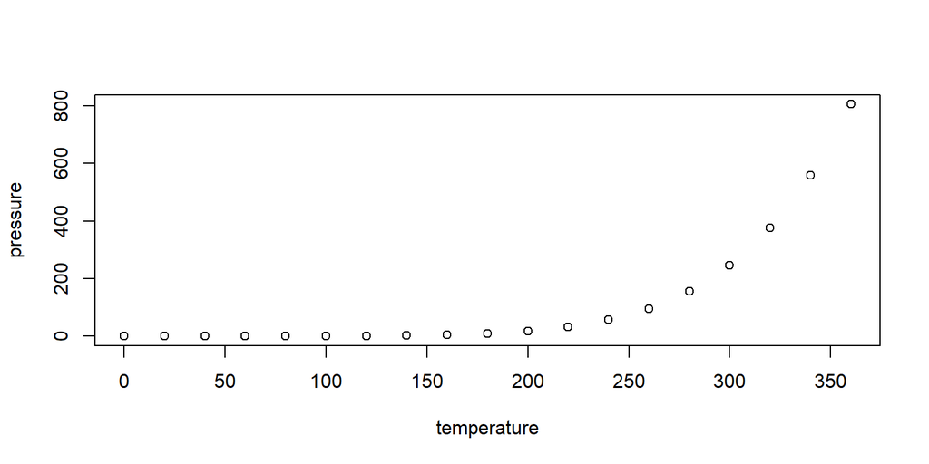

Abbildung 1: Vapor Pressure of Mercury as a Function of Temperature

### multiple plots

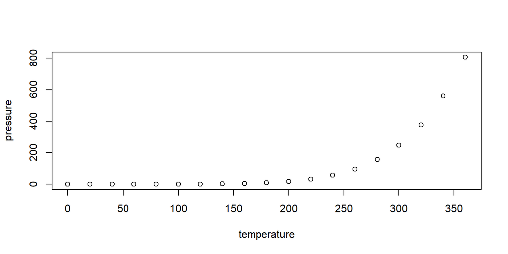

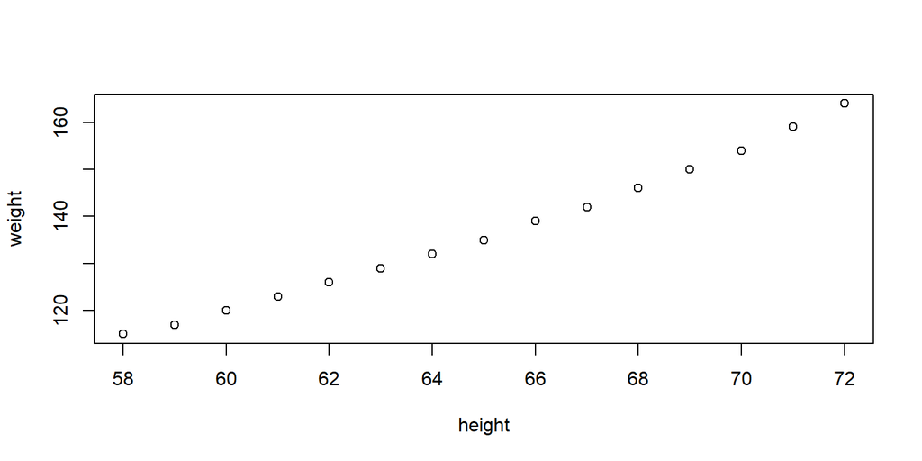

### image function works too

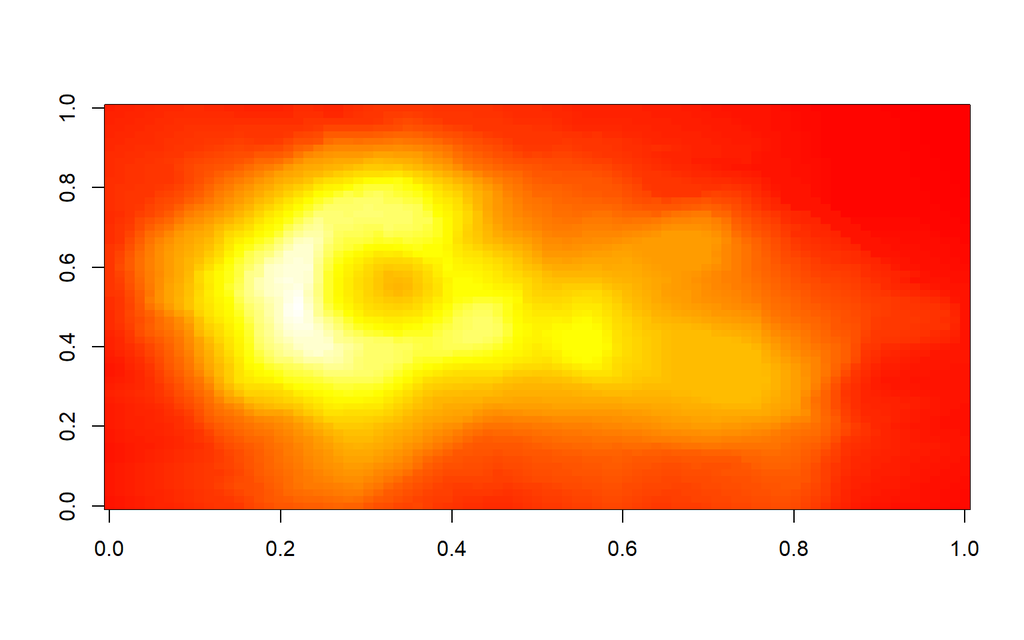

Abbildung 3: Vulkan mit heat.colors(200)

Back to Test Links

## external image

### knitr::include_graphics

[figure not shown]

Abbildung 5: Ostluft Logo with `knitr::include_graphics`

Back to Test Links

## NO cross references

### dont include chunks without a label

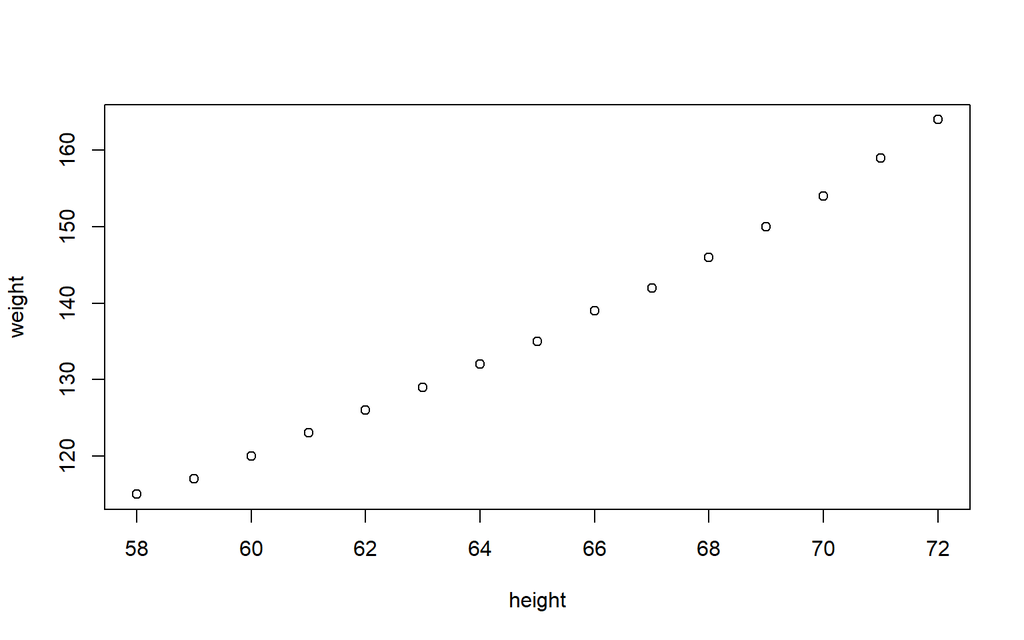

Average Heights and Weights for American Women

### dont include chunks with options crossref=FALSE

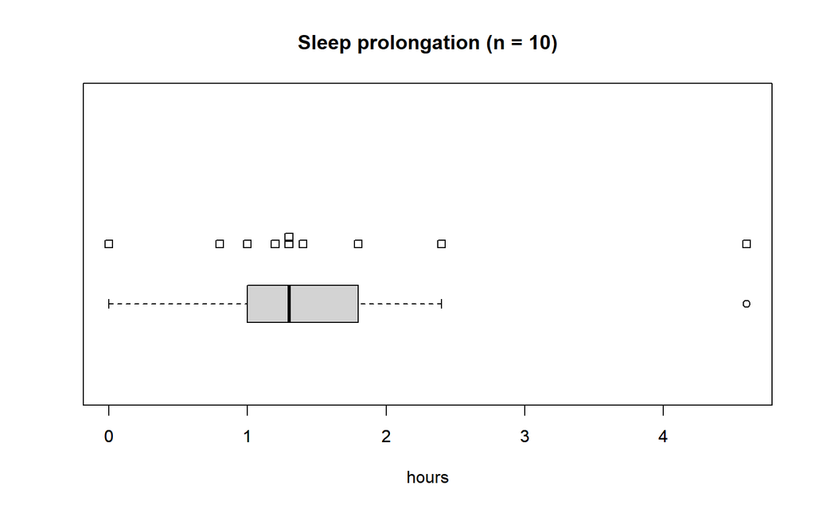

Sleep prolongation

Back to Test Links

# Markdown Format & Syntax Examples

## Code and tables

### Syntax highlighting

Here is a sample code chunk, just to show that syntax highlighting works as expected.

Code Block 1: Syntax highlighting

```r
library(ggplot2)
library(dplyr)
not_null <- function(v) {
    if (!is.null(v))
        return(paste(v, "not null"))
}
data(iris)
tab <- iris %>% group_by(Species) %>% summarise(Sepal.Length = mean(Sepal.Length),
    Sepal.Width = mean(Sepal.Width), Petal.Length = mean(Petal.Length), Petal.Width = mean(Petal.Length))
```

### Verbatim

Here is the structure of the `iris` dataset.

```r
str(iris)
```

Code Block 2: `ECHO=TRUE`

```
'data.frame':   150 obs. of  5 variables:
 $ Sepal.Length: num  5.1 4.9 4.7 4.6 5 5.4 4.6 5 4.4 4.9 ...
 $ Sepal.Width : num  3.5 3 3.2 3.1 3.6 3.9 3.4 3.4 2.9 3.1 ...
 $ Petal.Length: num  1.4 1.4 1.3 1.5 1.4 1.7 1.4 1.5 1.4 1.5 ...
 $ Petal.Width : num  0.2 0.2 0.2 0.2 0.2 0.4 0.3 0.2 0.2 0.1 ...
 $ Species     : Factor w/ 3 levels "setosa","versicolor",..: 1 1 1 1 1 1 1 1 1 1 ...
```

And blockquote :

> Oh ! What a nice blockquote you have here. Much more wonderful than a classical Lorem Ipsum, really. And we could also [include links](https://github.com/juba/rmdformats) or simply URLs like this : https://github.com/juba/rmdformats

### Table

Here is a sample table output.

Tabelle 1: `kable` cross reference example

[output not shown]

Here is a sample `DT::datatable` output[^1].

[output not shown]

Here we display a crosstab displayed in several different ways with a “pills” interface. To do this, just pass your `table()` result to the `pilltabs()` function.

- Count
- Rows %
- Columns %
- Residuals

|  | (4.3,5.5] | (5.5,6.7] | (6.7,7.9] |
| --- | --- | --- | --- |
| setosa | 47 | 3 | 0 |
| versicolor | 11 | 36 | 3 |
| virginica | 1 | 32 | 17 |

|  | (4.3,5.5] | (5.5,6.7] | (6.7,7.9] | Total | n |
| --- | --- | --- | --- | --- | --- |
| setosa | 94.0 | 6.0 | 0.0 | 100 | 50 |
| versicolor | 22.0 | 72.0 | 6.0 | 100 | 50 |
| virginica | 2.0 | 64.0 | 34.0 | 100 | 50 |
| All | 39.3 | 47.3 | 13.3 | 100 | 150 |

|  | (4.3,5.5] | (5.5,6.7] | (6.7,7.9] | All |
| --- | --- | --- | --- | --- |
| setosa | 79.7 | 4.2 | 0 | 33.3 |
| versicolor | 18.6 | 50.7 | 15 | 33.3 |
| virginica | 1.7 | 45.1 | 85 | 33.3 |
| Total | 100.0 | 100.0 | 100 | 100.0 |
| n | 59.0 | 71.0 | 20 | 150.0 |

|  | (4.3,5.5] | (5.5,6.7] | (6.7,7.9] |
| --- | --- | --- | --- |
| setosa | 6.16 | -4.25 | -2.58 |
| versicolor | -1.95 | 2.54 | -1.42 |
| virginica | -4.21 | 1.71 | 4.00 |

X-squared = 111.6339, df = 4, p = < 2.2e-16

## Mathjax

An incredibly complex equation :

$$x = \frac{-b \pm \sqrt{b^2-4ac}}{2a}\qquad(1)$$

## Figures

Here is an histogram.

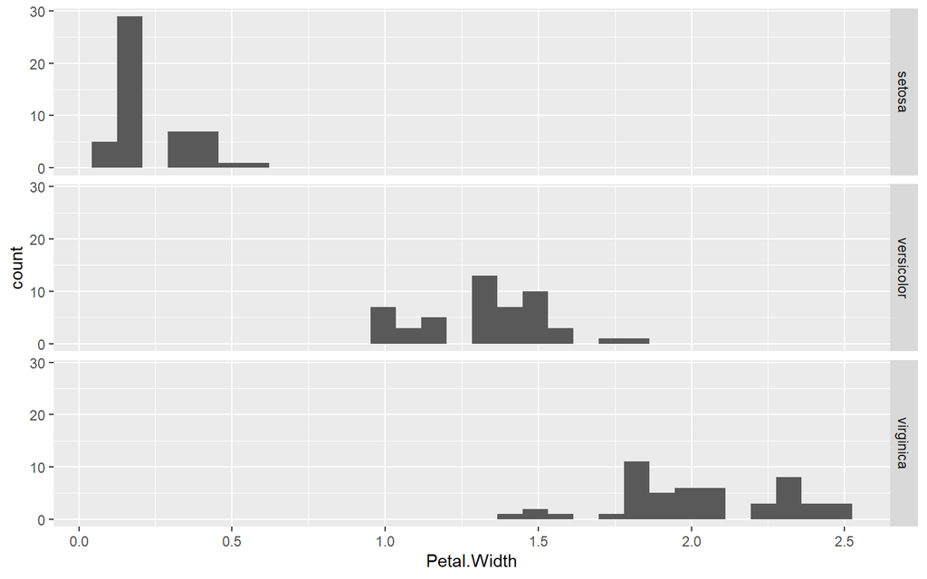

And a wonderful scatterplot, with a caption.

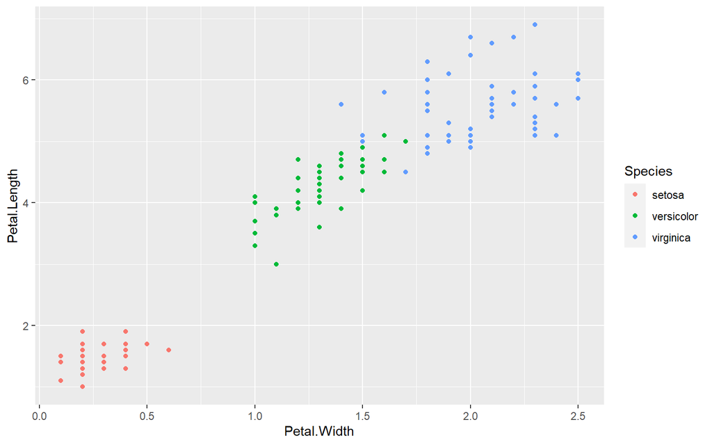

Abbildung 6: This is a caption

# Lightbox Plugin

Using the [Magnific popup](http://dimsemenov.com/plugins/magnific-popup/) lightbox plugin for plots and images. To enable the plugin set `lightbox: TRUE` and for gallery support `gallery: TRUE` in the yaml header. To suppress the lightbox for a plot or image add the class `"no-image-lb"`.

## Caption

Extracts the html from the figure caption. You can use any inline markdown syntax:

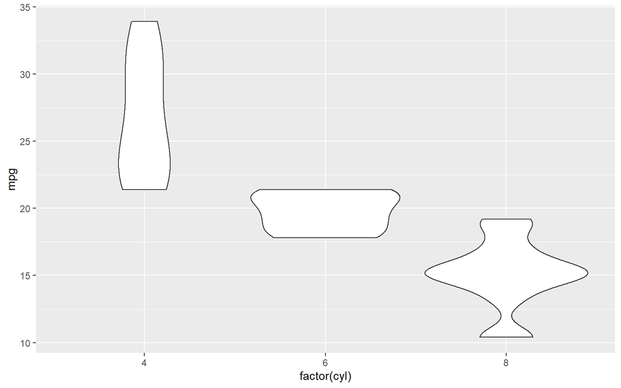

Abbildung 7: For more *Infos* **about** Violin plots see [ggplot2 reference](https://ggplot2.tidyverse.org/reference/geom_violin.html). Inline markdown: Superscripts 2<sup>nd</sup>, Subcripts H<sub>2</sub>O, inline TeX math $2 + 2$, inline Code `echo 'hello'` and even footnotes[^2]

## Suppress lightbox

Adding the class `no-image-lb` to the image (with the pandoc extension: [link_attributes](https://pandoc.org/MANUAL.html#other-extensions)) or plot (with `out.extra='class="no-image-lb"'`)

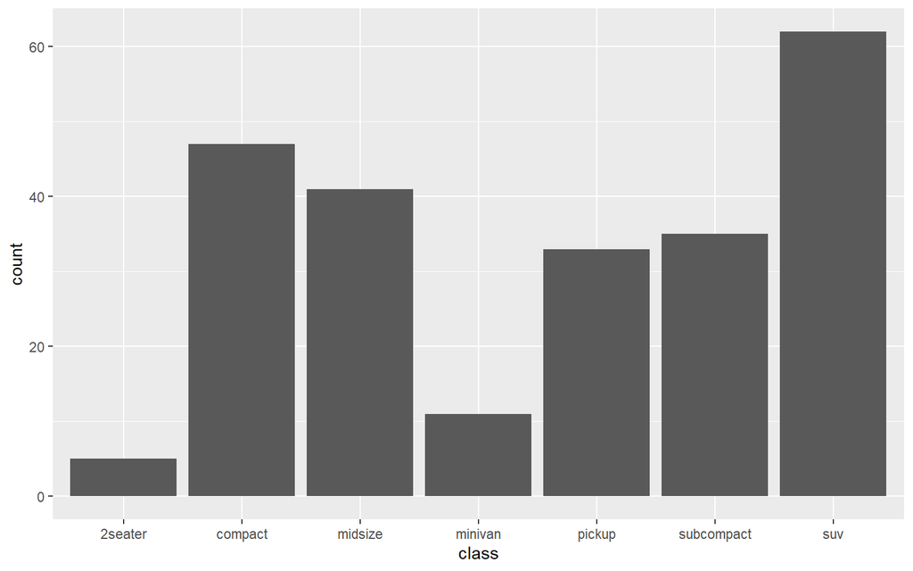

Abbildung 9: Number of cars in each class without lightbox

[^1]: cross referencing html tables isn’t [possible with pandoc-crossref](https://github.com/lierdakil/pandoc-crossref/issues/122)
[^2]: Footnote in figure caption